# Online Retail detailed EDA

## Introduction

This is a transnational data set which contains all the transactions occurring between 01/12/2010 and 09/12/2011 for a UK-based and registered non-store online retail. The company mainly sells unique all-occasion gifts. Many customers of the company are wholesalers. Online retail data set is extracted from University of California, Irwin machine learning repository. Data set is also present on www.kaggle.com/jihyeseo/online-retail-data-set-from-uci-ml-repo.

The purpose of the data analysis is to capture the insights with the business data, which can be used in making the business oriented decisions. The major part of the analysis consist of exploratory data analysis, data wrangling as they are basic and important steps for data science projects.

The motive here is to analyze the sales happening on monthly, daily and hourly basis. On the basis of which we can further think of predicting the future sales. This online data is of ocassional gifts ordered by various customers across various countries.

## Data Preparations

Data prepration is important to make sure we are going forward with the right data and donot mess up when deriving the conclusion.

Let’s take a dive and figure out what are various features pressent, various anomalies in the data set. Starting by loading library “tidyverse”, loading the online retail data and checking the summary of the data.

```r
# loading library tidyverse
library(tidyverse)
library(lubridate)
# load the data
data <- read_csv("online_retail.csv")
```

## Data set Column Description

1. InvoiceNo Invoice- number. Nominal, a 6-digit integral number uniquely assigned to each transaction. If this code starts with letter ‘c’, it indicates a cancellation.
2. StockCode Product (item) code- 5-digit integral number uniquely assigned to each distinct product.
3. Description Product (item) name- Nominal.
4. Quantity- The quantities of each product (item) per transaction.
5. InvoiceDate- The day and time when each transaction was generated.
6. UnitPrice- Product price per unit in sterling.
7. CustomerID- Nominal, a 5-digit integral number uniquely assigned to each customer.
8. Country- The name of the country where each customer resides.

```r
# summary of the data
summary(data)
```

```
##   InvoiceNo          StockCode         Description
##  Length:541909      Length:541909      Length:541909
##  Class :character   Class :character   Class :character
##  Mode  :character   Mode  :character   Mode  :character
##
##
##
##
##     Quantity         InvoiceDate          UnitPrice
##  Min.   :-80995.00   Length:541909      Min.   :-11062.06
##  1st Qu.:     1.00   Class :character   1st Qu.:     1.25
##  Median :     3.00   Mode  :character   Median :     2.08
##  Mean   :     9.55                      Mean   :     4.61
##  3rd Qu.:    10.00                      3rd Qu.:     4.13
##  Max.   : 80995.00                      Max.   : 38970.00
##
##    CustomerID       Country
##  Min.   :12346    Length:541909
##  1st Qu.:13953    Class :character
##  Median :15152    Mode  :character
##  Mean   :15288
##  3rd Qu.:16791
##  Max.   :18287
##  NA's   :135080
```

In a single glance it is clear that there is something not right with Quantity and Unit Price. Let’s check for NA values. Looking at the data rows and columns

```r
#how many rows are present
nrow(data)
```

```
## [1] 541909
```

```r
#how many columns
ncol(data)
```

```
## [1] 8
```

```r
#look at the first 6 rows
head(data)
```

```
## # A tibble: 6 x 8
##   InvoiceNo StockCode Description Quantity InvoiceDate UnitPrice CustomerID
##   <chr>     <chr>     <chr>          <dbl> <chr>           <dbl>      <dbl>
## 1 536365    85123A    WHITE HANG~        6 12/01/10 0~      2.55      17850
## 2 536365    71053     WHITE META~        6 12/01/10 0~      3.39      17850
## 3 536365    84406B    CREAM CUPI~        8 12/01/10 0~      2.75      17850
## 4 536365    84029G    KNITTED UN~        6 12/01/10 0~      3.39      17850
## 5 536365    84029E    RED WOOLLY~        6 12/01/10 0~      3.39      17850
## 6 536365    22752     SET 7 BABU~        2 12/01/10 0~      7.65      17850
## # ... with 1 more variable: Country <chr>
```

Checking for NA values

```r
# number of NA vlaues
data %>% is.na %>% colSums
```

```
##   InvoiceNo   StockCode Description    Quantity InvoiceDate   UnitPrice
##           0           0        1454           0           0           0
##  CustomerID     Country
##      135080           0
```

CustomerID variable doesn’t seems to be necessary can be removed as there are n mumber of customers and there is nothing much to evaluate from them. NA values are present in Discription also. We are not removing NA values of Descriptions there are many more categories of missing values and Unit Price of them is 0. So, all the unwanted values in description will be gone once we values of UnitPrice= 0. As they will not contribute in calculating sales.

## Data Cleaning

Check the summary of data

```r
# remove free orders
data <- data %>%
  filter(UnitPrice != 0)

#removing the CustomerID
data<- data %>% select(-c(CustomerID))

#summary
summary(data)
```

```
##   InvoiceNo          StockCode         Description
##  Length:539394      Length:539394      Length:539394
##  Class :character   Class :character   Class :character
##  Mode  :character   Mode  :character   Mode  :character
##
##
##
##     Quantity         InvoiceDate          UnitPrice
##  Min.   :-80995.00   Length:539394      Min.   :-11062.06
##  1st Qu.:     1.00   Class :character   1st Qu.:     1.25
##  Median :     3.00   Mode  :character   Median :     2.08
##  Mean   :     9.85                      Mean   :     4.63
##  3rd Qu.:    10.00                      3rd Qu.:     4.13
##  Max.   : 80995.00                      Max.   : 38970.00
##    Country
##  Length:539394
##  Class :character
##  Mode  :character
##
##
##
```

Checking for NA values

```r
# number of NA vlaues
data %>% is.na %>% colSums
```

```
##   InvoiceNo   StockCode Description    Quantity InvoiceDate   UnitPrice
##           0           0           0           0           0           0
##     Country
##           0
```

all the NA values are removed.

## Data Pre-processing-1 for single variate plot.

Pre-processing of data is required for single variable EDA to figure out the outliers, not required categories in order to calcualte the total sales over the period of time.

```r
######### Pre processing-1 of data

#Transform description and country column as factor
data <- data %>%mutate(Description = as.factor(Description),
                       Country = as.factor(Country))

# Hourly, daily and monthly split of date time for Invoice date will be used in single and multivariable plot.
data$InvoiceDate <- mdy_hm(data$InvoiceDate)
data$date <- format(data$InvoiceDate, "%m/%d/%Y")
data$month <- format(data$InvoiceDate, "%B")
data$week <- format(data$InvoiceDate, "%A")
data$time <- format(data$InvoiceDate, "%H")

#total sales
data$Total_sales = data$Quantity * data$UnitPrice

#summary of data
head(data)
```

```
## # A tibble: 6 x 12
##   InvoiceNo StockCode Description Quantity InvoiceDate         UnitPrice
##   <chr>     <chr>     <fct>          <dbl> <dttm>                  <dbl>
## 1 536365    85123A    WHITE HANG~        6 2010-12-01 08:26:00      2.55
## 2 536365    71053     WHITE META~        6 2010-12-01 08:26:00      3.39
## 3 536365    84406B    CREAM CUPI~        8 2010-12-01 08:26:00      2.75
## 4 536365    84029G    KNITTED UN~        6 2010-12-01 08:26:00      3.39
## 5 536365    84029E    RED WOOLLY~        6 2010-12-01 08:26:00      3.39
## 6 536365    22752     SET 7 BABU~        2 2010-12-01 08:26:00      7.65
## # ... with 6 more variables: Country <fct>, date <chr>, month <chr>,
## #   week <chr>, time <chr>, Total_sales <dbl>
```

Seems like we have sufficient data for single variable analysis to find out the outliers, unwanted values.

## Single variable EDA

1. Defining the customer base across the countries

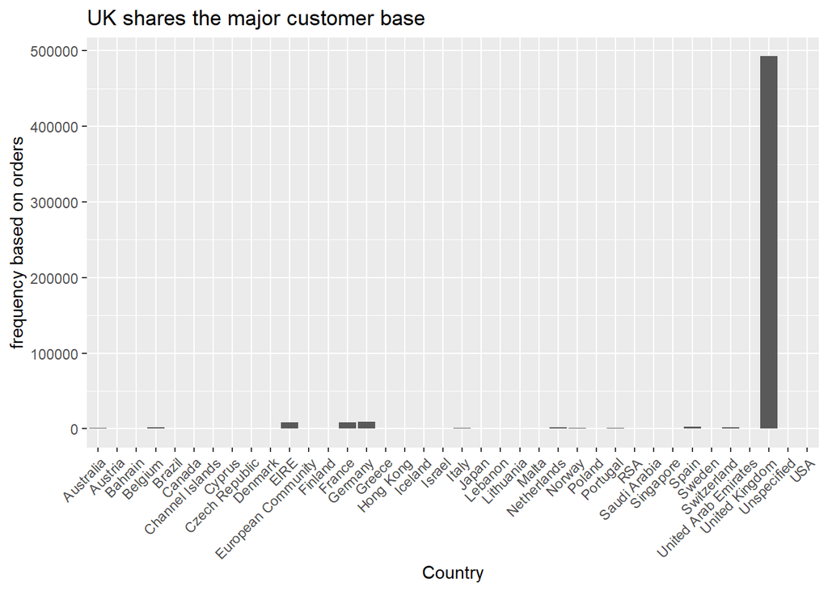

```r
# Customer base by countries
ggplot(data=data, aes(x=Country))+
  geom_bar()+
  theme(axis.text.x = element_text(angle = 45, vjust = 1, hjust = 1))+
  scale_y_continuous(labels = scales::format_format(scientific = FALSE))+
  ggtitle("UK shares the major customer base")+
  ylab("frequency based on orders")
```

The above graphs displays that UK has the major portion of the customers with respect to other countries. Let’s see the plot without the UK customer base

2. Defining the customer base across the countries(without UK)

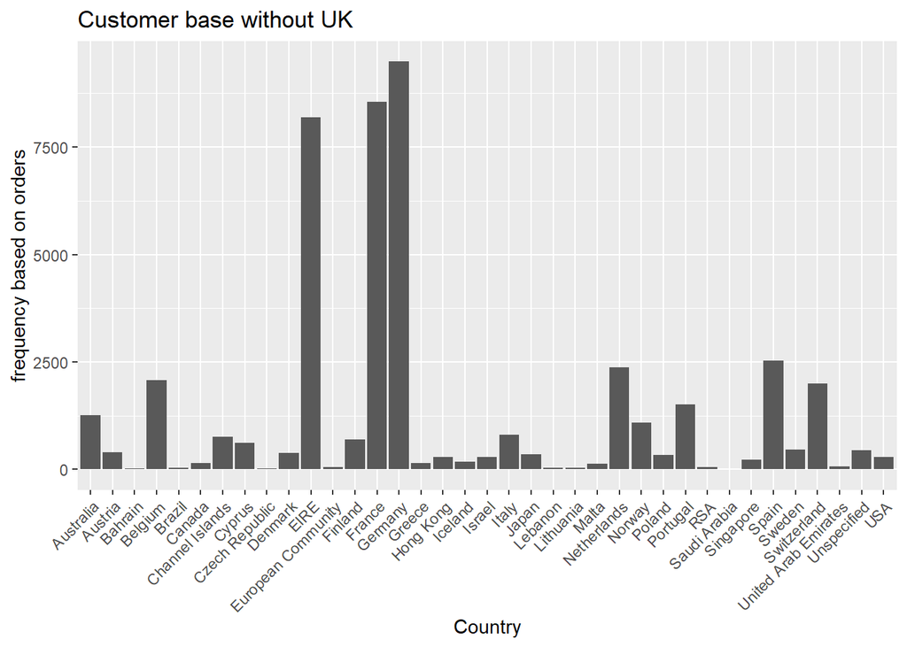

```r
# Customer base by country without UK
p1 <- data %>% filter (Country != "United Kingdom") %>%
  ggplot(aes(x=Country))+
  geom_bar()+
  theme(axis.text.x = element_text(angle = 45, vjust = 1, hjust = 1))+
  ggtitle("Customer base without UK")+
  ylab("frequency based on orders")
p1
```

The above graphs displays that Germany, France and Ireland are top 3 countries where online retail is working but it’s very low in comparison to UK. So, we should be focusing on UK only. Removal of all other countries will be done in pre-processing-2

3. Single variable plot for most sold Product Stock Code

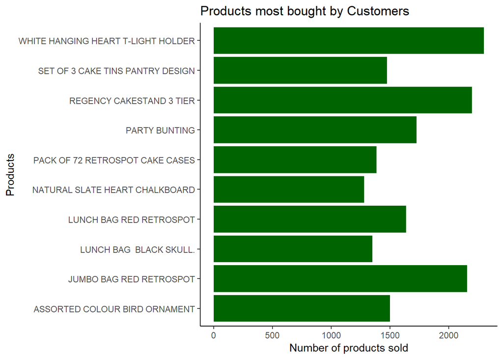

```r
# extracting the products with the help of stockcode
#top 10 products
p3 <- data %>% group_by(Description, StockCode) %>%
  summarise(count = n()) %>%
  arrange(desc(count)) %>%
  head(10)

# plot
p3 %>% ggplot(aes(x= Description, y= count))+
  geom_bar(stat = 'identity', fill = "darkgreen") +
  coord_flip() + theme_classic()+
  xlab("Products")+
  ylab("Number of products sold")+
  ggtitle("Products most bought by Customers")
```

Above graph represents the top 10 products which are mostly ordered by users.

4. Single variable plot in which hours the maxixmum orders are placed

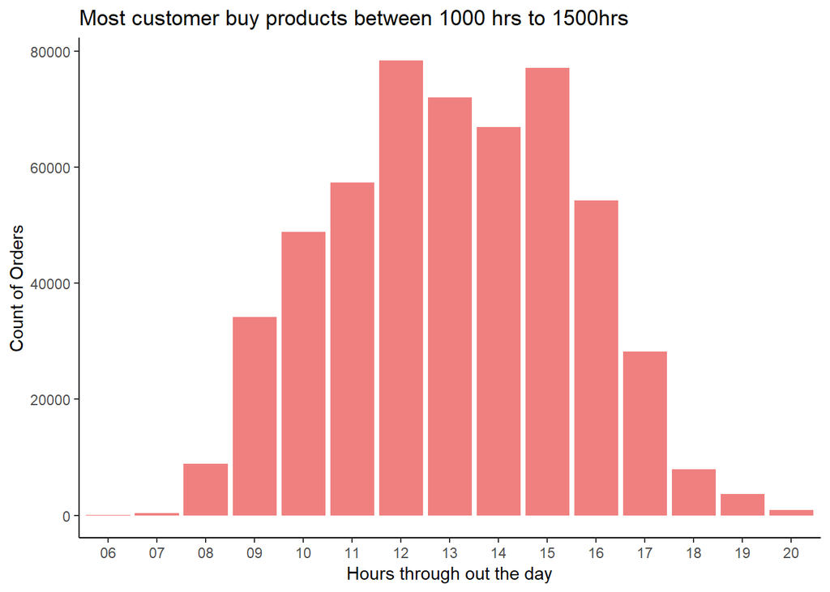

```r
# what time most products are sold
ggplot(data= data, aes(x=time))+
  geom_histogram(stat = "count", fill = "lightcoral")+
  theme_classic()+
  xlab("Hours through out the day")+
  ylab("Count of Orders")+
  ggtitle("Most customer buy products between 1000 hrs to 1500hrs")
```

The above graph explains that between morning 10 am till 3pm most of the orders are placed on the online portal(from every country).

5. Single variable plot for Cancelled orders

It’s time to dig a little deeper and dig into analysis of Cancelled orders.

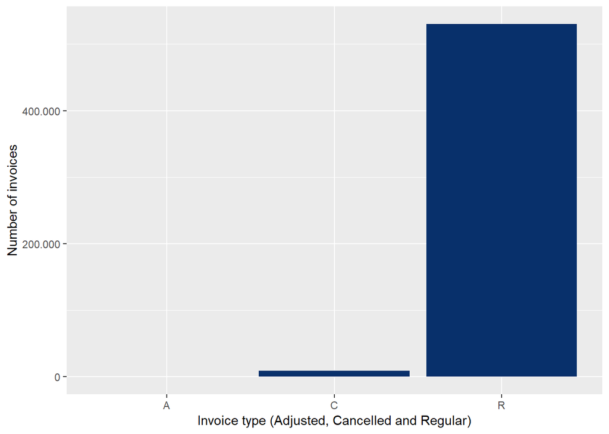

```r
#Seperating cancelled, Adjusted and Regular orders
data <- data %>% mutate(InvoicePrefix = ifelse(substr(InvoiceNo,1,1) %in% letters | substr(InvoiceNo,1,1) %in% LETTERS, substr(InvoiceNo,1,1), "R"))

#plot
ggplot(data = data, aes(x=InvoicePrefix))+
  geom_bar(position = "dodge", fill = "#08306b")+
  scale_y_continuous(labels = scales::format_format(big.mark = ".", decimal.mark = ",", scientific = FALSE))+ labs(x = "Invoice type (Adjusted, Cancelled and Regular)", y = "Number of invoices")
```

## Data pre-processing-2 for multivariate EDA

Let’s remove the outliers present and investigate the errors stepwise 1. What all products contibute to top 20 sales

```r
#Step-1
#products contribute most to sales
top20_product_sales <- data %>%
  select(StockCode, Description, Total_sales)%>%
  group_by(StockCode, Description, Total_sales) %>%
  filter(rank(desc(Total_sales)) <= 20) %>%
  arrange(desc(Total_sales)) %>%
  head(20)
head(top20_product_sales, 20)
```

```
## # A tibble: 20 x 3
## # Groups:   StockCode, Description, Total_sales [19]
##    StockCode Description                         Total_sales
##    <chr>     <fct>                                     <dbl>
##  1 23843     PAPER CRAFT , LITTLE BIRDIE             168470.
##  2 23166     MEDIUM CERAMIC TOP STORAGE JAR           77184.
##  3 22502     PICNIC BASKET WICKER 60 PIECES           38970
##  4 AMAZONFEE AMAZON FEE                               13541.
##  5 B         Adjust bad debt                          11062.
##  6 POST      POSTAGE                                   8143.
##  7 23243     SET OF TEA COFFEE SUGAR TINS PANTRY       7145.
##  8 21108     FAIRY CAKE FLANNEL ASSORTED COLOUR        6539.
##  9 21108     FAIRY CAKE FLANNEL ASSORTED COLOUR        6539.
## 10 23084     RABBIT NIGHT LIGHT                        4992
## 11 85123A    WHITE HANGING HEART T-LIGHT HOLDER        4922.
## 12 22086     PAPER CHAIN KIT 50'S CHRISTMAS            4782.
## 13 85123A    WHITE HANGING HEART T-LIGHT HOLDER        4632
## 14 48185     DOORMAT FAIRY CAKE                        4522.
## 15 DOT       DOTCOM POSTAGE                            4505.
## 16 23173     REGENCY TEAPOT ROSES                      4401
## 17 M         Manual                                    4288.
## 18 48185     DOORMAT FAIRY CAKE                        4254.
## 19 84879     ASSORTED COLOUR BIRD ORNAMENT             4176
## 20 M         Manual                                    4161.
```

These seems to be like bad adjustments, Amazon fee, Postage, Manual, Dotcom Postage are not the actual contributors to the sale. We’ll be removing the observations relating to them. But first checking the relation of cancelled orders with top grossing sales by comparing the exact total sales amount.

```r
#Step-2
# Selecting top total sales with respective invoices tocheck for cancelled orders
p4 <- data %>%
  select(InvoiceNo, StockCode, Description, Quantity, Total_sales, InvoicePrefix)%>%
  filter(abs(Total_sales) %in% c(168469.60, 77183.60, 38970.00, 13541.33, 11062.06, 8142.75, 7144.72, 6539.40, 4992.00, 4921.50, 4781.60, 4632.00, 4522.50, 4401.00, 4287.63, 4254.50, 4176.00, 4161.06)) %>%
  arrange(desc(abs(Total_sales)))
p4
```

```
## # A tibble: 28 x 6
##    InvoiceNo StockCode Description       Quantity Total_sales InvoicePrefix
##    <chr>     <chr>     <fct>                <dbl>       <dbl> <chr>
##  1 581483    23843     PAPER CRAFT , LI~    80995     168470. R
##  2 C581484   23843     PAPER CRAFT , LI~   -80995    -168470. C
##  3 541431    23166     MEDIUM CERAMIC T~    74215      77184. R
##  4 C541433   23166     MEDIUM CERAMIC T~   -74215     -77184. C
##  5 556444    22502     PICNIC BASKET WI~       60      38970  R
##  6 C556445   M         Manual                  -1     -38970  C
##  7 C537630   AMAZONFEE AMAZON FEE              -1     -13541. C
##  8 537632    AMAZONFEE AMAZON FEE               1      13541. R
##  9 C537651   AMAZONFEE AMAZON FEE              -1     -13541. C
## 10 A563185   B         Adjust bad debt          1      11062. A
## # ... with 18 more rows
```

Ah.Okay! We can clearly see that the top 3 earning highest total sales are cancelled orders rest of them are majorly cancelled, adjust bad debts, Amazon fee, Manual, Postage fee. Let’s remove the Stockcode which donot contribute to Total sales. Remove particular Invoices which are cancelled and rest of them looks fine as there is no relation to it.

Cleaning the unwanted orders and top cancelled orders

```r
# Step-3
## removing all the products wrongly contributing to sales
data <- data %>%
  filter(!StockCode %in% c("DOT", "POST", "M", "AMAZONFEE", "B"))

# Specific Invoices are deleted
data <- data[!(data$InvoiceNo=="581483"),]
data <- data[!(data$InvoiceNo=="C581484"),]
data <- data[!(data$InvoiceNo=="541431"),]
data <- data[!(data$InvoiceNo=="C541433"),]
data <- data[!(data$InvoiceNo=="556444"),]
data <- data[!(data$InvoiceNo=="540815"),]
data <- data[!(data$InvoiceNo=="C550456"),]
data <- data[!(data$InvoiceNo=="C550456"),]
data <- data[!(data$InvoiceNo=="C550456"),]

# again checking the top products
#products contribute most to sales
top20_product_sales <- data %>%
  select(StockCode, Description, Total_sales)%>%
  group_by(StockCode, Description, Total_sales) %>%
  filter(rank(desc(Total_sales)) <= 20) %>%
  arrange(desc(Total_sales)) %>%
  head(20)
head(top20_product_sales, 20)
```

```
## # A tibble: 20 x 3
## # Groups:   StockCode, Description, Total_sales [20]
##    StockCode Description                         Total_sales
##    <chr>     <fct>                                     <dbl>
##  1 23243     SET OF TEA COFFEE SUGAR TINS PANTRY       7145.
##  2 21108     FAIRY CAKE FLANNEL ASSORTED COLOUR        6539.
##  3 23084     RABBIT NIGHT LIGHT                        4992
##  4 22086     PAPER CHAIN KIT 50'S CHRISTMAS            4782.
##  5 85123A    WHITE HANGING HEART T-LIGHT HOLDER        4632
##  6 48185     DOORMAT FAIRY CAKE                        4522.
##  7 23173     REGENCY TEAPOT ROSES                      4401
##  8 48185     DOORMAT FAIRY CAKE                        4254.
##  9 84879     ASSORTED COLOUR BIRD ORNAMENT             4176
## 10 22470     HEART OF WICKER LARGE                     4122.
## 11 22413     METAL SIGN TAKE IT OR LEAVE IT            3861
## 12 21623     VINTAGE UNION JACK MEMOBOARD              3828
## 13 23113     PANTRY CHOPPING BOARD                     3825.
## 14 22328     ROUND SNACK BOXES SET OF 4 FRUITS         3794.
## 15 23084     RABBIT NIGHT LIGHT                        3652.
## 16 22722     SET OF 6 SPICE TINS PANTRY DESIGN         3621
## 17 22197     POPCORN HOLDER                            3549
## 18 21175     GIN + TONIC DIET METAL SIGN               3380
## 19 22086     PAPER CHAIN KIT 50'S CHRISTMAS            3322.
## 20 47556B    TEA TIME TEA TOWELS                       3315.
```

Now this seems to be legit total sales data from which multivariate analysis will be done monthly, daily and hourly.

Removing the variables which will not be used further, considering only UK data for further analysis.

```r
# Step-4
# Filtering only UK data
data <- data %>% filter(Country == "United Kingdom")

# removing the variables which will not be needed
data<- data %>% select(-c(Country, Description, StockCode, InvoiceDate, InvoicePrefix))

head(data)
```

```
## # A tibble: 6 x 8
##   InvoiceNo Quantity UnitPrice date      month   week     time  Total_sales
##   <chr>        <dbl>     <dbl> <chr>     <chr>   <chr>    <chr>       <dbl>
## 1 536365           6      2.55 12/01/20~ Decemb~ Wednesd~ 08           15.3
## 2 536365           6      3.39 12/01/20~ Decemb~ Wednesd~ 08           20.3
## 3 536365           8      2.75 12/01/20~ Decemb~ Wednesd~ 08           22
## 4 536365           6      3.39 12/01/20~ Decemb~ Wednesd~ 08           20.3
## 5 536365           6      3.39 12/01/20~ Decemb~ Wednesd~ 08           20.3
## 6 536365           2      7.65 12/01/20~ Decemb~ Wednesd~ 08           15.3
```

All the unwanted variables are gone and only UK data is present.

## Multi variable EDA

1. Plotting the total sales on monthly basis

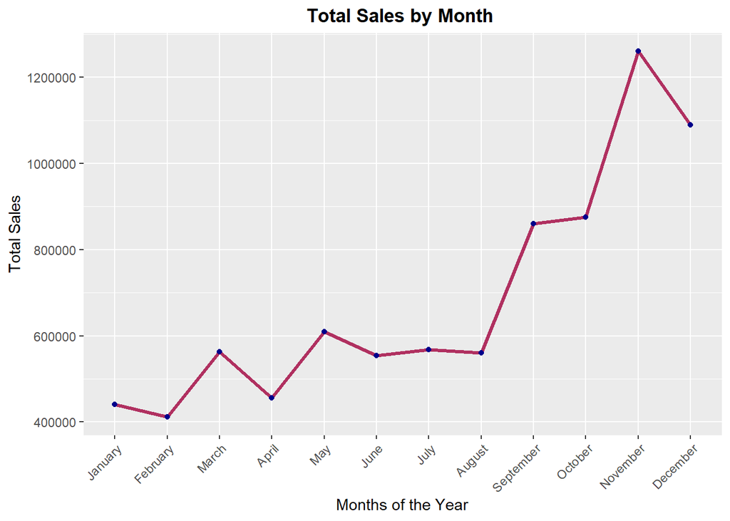

```r
# Multiple variable EDA

# calculating the total sales by month
data2 <- data %>%
  group_by(month)%>%
  summarise(Total_sales=sum(Total_sales))%>%
  arrange(match(month, month.name))

#Line plot
ggplot(data=data2,aes(x=ordered(month, month.name), y=Total_sales, group =1))+ggtitle("Total Sales by Month ")+
  geom_line(colour = "maroon", size = 1.2)+
  geom_point(color="darkblue")+
  theme(axis.text.x = element_text(angle = 45, vjust = 1, hjust = 1),plot.title = element_text(hjust=0.5, lineheight = 0.8, face = "bold"))+
  ylab("Total Sales") + xlab("Months of the Year")
```

The above graph shows that from September to December the sale is high in comparison to other months of the year. November is the peak season. Reason can be due to fall festivals like (christmas, New year, Thanksgiving, Halloween). Gift purchasing is on the rise.

2. Plotting the total sales on daily basis

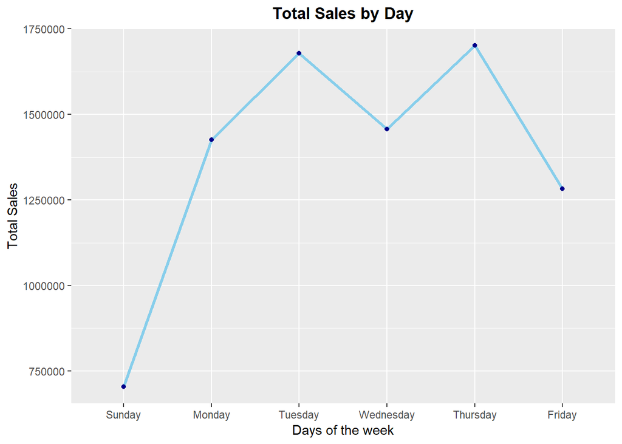

```r
# Multiple variable EDA

# calculating total sales on daily basis
daywise <- data %>%
  group_by(week)%>%
  summarise(Total_sales=sum(Total_sales))%>%
  arrange(week)

#reorder the table according to Weekdays, so that when it comes to data visualization the weekdays will be in the right order
daywise$week<- factor(daywise$week,
                      levels=c("Sunday","Monday","Tuesday", "Wednesday", "Thursday", "Friday", "Saturday"))

daywise<-daywise[order(daywise$week),]

#Line plot
ggplot(data=daywise,aes(x=week, y=Total_sales, group =1))+ggtitle("Total Sales by Day")+
  geom_line(colour = "skyblue", size = 1.2)+
  geom_point(color="darkblue")+
  theme(plot.title = element_text(hjust=0.5, lineheight = .8, face = "bold"))+
  ylab("Total Sales") + xlab("Days of the week")
```

The above graph shows that Tuesday’s and Thursday’s are the days where more Total Sale is happening in comparison to other weekdays. Saturday seems to be off for orders.

3. Plotting the total sales on hourly basis

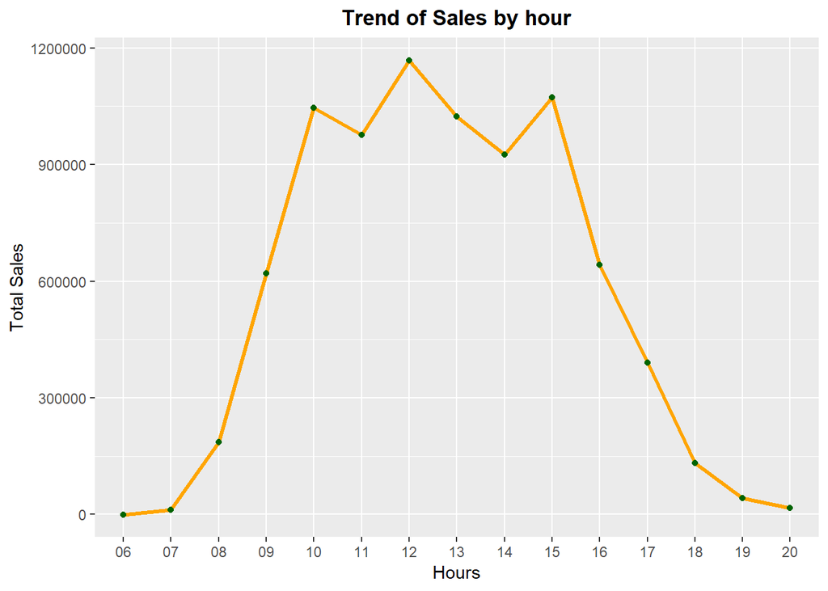

```r
# Multiple variable EDA

# calculating total sales on hourly basis
hourly<- data %>%
  group_by(time)%>%
  summarise(Total_sales=sum(Total_sales))

#line plot
ggplot(data=hourly,aes(x=time, y=Total_sales, group =1))+ggtitle("Trend of Sales by hour")+
  geom_line(colour = "orange", size = 1.2)+
  geom_point(color="dark green")+
  theme(plot.title = element_text(hjust=0.5, lineheight = .8, face = "bold"))+
  ylab("Total Sales") + xlab("Hours")
```

The above line plot gives the clear picture that 1000hrs to 1500hrs generate the most of sales during the day. This implicates the behaviour of the customers, major section id active during the office hours.

From the above analysis of single variable and multi variable EDA, basic focus is to identify how the sale is happening over the time. The perfect idea we get due to busy delivery system at the time of holidays, people tend to order in November for most of the holidays. The steep increase in sales in November can also be due to the sale season. Special sale for holidays is always considered as one of the best ideas.